# LongReads_Fungi_study

Arthur Monjot

2025-07-31

## I. Setup

### I.A. Working directory and seed

We define the working directory (i.e. *Long_Reads_Fungi/*) for the R analysis and create a *Outputs* folder in which the figures and other results will be generated.

```r
knitr::opts_chunk$set(echo = TRUE)
setwd(".")
if (dir.exists("Outputs/LongReads_analysis/") == FALSE) {system("mkdir -p Outputs/LongReads_analysis/")}
set.seed(123)
```

### I.B. Library

We import R package.

```r
# Packages
pkg <- c("ggplot2","data.table","dplyr","tidyr","tibble","stringr","elementalist","svglite","readxl","igraph","ggraph","tidygraph")
lapply(pkg, require, character.only = TRUE)
```

```
## [[1]]
## [1] TRUE
##
## [[2]]
## [1] TRUE
##
## [[3]]
## [1] TRUE
##
## [[4]]
## [1] TRUE
##
## [[5]]
## [1] TRUE
##
## [[6]]
## [1] TRUE
##
## [[7]]
## [1] TRUE
##
## [[8]]
## [1] TRUE
##
## [[9]]
## [1] TRUE
##
## [[10]]
## [1] TRUE
##
## [[11]]
## [1] TRUE
##
## [[12]]
## [1] TRUE
```

Each “TRUE” corresponds to the correct importation of each R package.

### I.C. Custom function

```r
# Theme graph
theme_unique_art_graph <- function (base_size = 12, base_family = "") {
  ret <- (theme_minimal(base_size = base_size, base_family = base_family) +
            theme(text = element_text(colour = "black"),
                  title = element_text(color = "black", face = "bold", vjust = 0.5, hjust = 0.5),
                  axis.ticks = element_blank(),
                  axis.text = element_blank(),
                  axis.title = element_blank(),
                  line = element_line(color = "black"),
                  rect = element_rect(fill = "white", color = "black"),
                  legend.background = element_blank(),
                  legend.key = element_rect(fill = NA, color = NA, linetype = 0),
                  legend.text = element_text(size = 8),
                  legend.title = element_text(size = 12, face="bold"),
                  panel.background = element_rect_round(radius = unit(0.5, "cm"),fill = "white", color = NULL,size = 1),
                  strip.text = element_text(size = 12,color="black",face="bold",vjust=.5,hjust=.5),
                  panel.border = element_blank(),
                  plot.background = element_rect(fill = "white", colour = "white", linetype = 0)))
  ret
}
```

## II. Charge raw table and formatting

We import the OTUs table for LR dataset.

```r
otu_table_LR <- readxl::read_xlsx("rawdata/OBAMA01_Boxes-4.xlsx",sheet = "OtuTable")
taxo_LR <- readxl::read_xlsx("rawdata/OBAMA01_Boxes-4.xlsx",sheet = "Taxonomy")
```

We then format table with adequate column and row names.

```r
## OTU table
otu_table_LR <- otu_table_LR %>% column_to_rownames("OTU")
otu_table_LR <- as.matrix(otu_table_LR)
colnames(otu_table_LR) <- gsub("T", "", colnames(otu_table_LR))
```

## III. Clustering analysis

### IV.A. Prepare LR otu table

```r
otu_table_LR <- merge(otu_table_LR, taxo_LR, by.x="row.names", by.y="OTU")
otu_table_LR <- otu_table_LR %>% mutate(Row.names=paste0("LR_",Row.names)) %>% column_to_rownames("Row.names") %>% select(-NegC_2,-TotalAbundance,-Occurrence)
otu_table_LR <- otu_table_LR %>% mutate(Taxo=paste("Eukaryota",Kingdom,Phylum,Class,Order,Family,Genus,Species,sep=";"))
```

### IV.B. Short read data

We import the OTUs table of SR dataset.

```r
phylo_rar <- readRDS("rawdata/phylo_rar.rds")
otu_table_SR_rar <- merge(phylo_rar@tax_table,phylo_rar@otu_table,by="row.names")
otu_table_SR_rar[otu_table_SR_rar==""] <- NA
otu_table_SR_rar <- otu_table_SR_rar %>% mutate(Row.names=paste0("SR_",Row.names)) %>% column_to_rownames("Row.names")
otu_table_SR_rar <- otu_table_SR_rar %>% mutate(Taxo=paste(Domain,Supergroup,Division,Subdivision,Class,Order,Family,Genus,Species,sep=";"))
otu_table_SR <- otu_table_SR_rar
```

### IV.C. Compute sedimentary unit and abundance for each ASVs

```r
sedimentary_file <- read.table("rawdata/sample_data_Thio.csv", sep = ";", header = TRUE)
SED_1 <- sedimentary_file[,"Sample_ID"][sedimentary_file[,"Part"]=="I"]
SED_2 <- sedimentary_file[,"Sample_ID"][sedimentary_file[,"Part"]=="II"]
SED_3 <- sedimentary_file[,"Sample_ID"][sedimentary_file[,"Part"]=="III"]
SED_4 <- sedimentary_file[,"Sample_ID"][sedimentary_file[,"Part"]=="IV"]
#SED_5 <- sedimentary_file[,"Sample_ID"][sedimentary_file[,"Part"]=="V"]
otu_table_LR_sed <- otu_table_LR %>%
  mutate(I=rowSums(otu_table_LR[,all_of(SED_1[SED_1 %in% colnames(otu_table_LR)])])) %>%
  mutate(II=rowSums(otu_table_LR[,all_of(SED_2[SED_2 %in% colnames(otu_table_LR)])])) %>%
  mutate(III=rowSums(otu_table_LR[,all_of(SED_3[SED_3 %in% colnames(otu_table_LR)])])) %>%
  mutate(IV=rowSums(otu_table_LR[,all_of(SED_4[SED_4 %in% colnames(otu_table_LR)])])) #%>%
  #mutate(V=rowSums(otu_table_LR[,all_of(SED_5[SED_5 %in% colnames(otu_table_LR)])]))
otu_table_SR_sed <- otu_table_SR %>%
  mutate(I=rowSums(as.data.frame(lapply((otu_table_SR[,all_of(SED_1[SED_1 %in% colnames(otu_table_SR)])]),as.numeric)))) %>%
  mutate(II=rowSums(as.data.frame(lapply((otu_table_SR[,all_of(SED_2[SED_2 %in% colnames(otu_table_SR)])]),as.numeric)))) %>%
  mutate(III=rowSums(as.data.frame(lapply((otu_table_SR[,all_of(SED_3[SED_3 %in% colnames(otu_table_SR)])]),as.numeric)))) %>%
  mutate(IV=rowSums(as.data.frame(lapply((otu_table_SR[,all_of(SED_4[SED_4 %in% colnames(otu_table_SR)])]),as.numeric)))) #%>%
  #mutate(V=rowSums(as.data.frame(lapply((otu_table_SR[,all_of(SED_5[SED_5 %in% colnames(otu_table_SR)])]),as.numeric))))
```

### III.A. Join taxonomy and Charge the 656 ASVs

```r
taxo_file <- rbind(otu_table_LR_sed %>% select(Taxo,I,II,III,IV),otu_table_SR_sed %>% select(Taxo,I,II,III,IV))
nrow(taxo_file)
```

```
## [1] 21611
```

There is 21611 LR and SR.

We import the list of ASVs (i.e. 656 ASVs) which are differentially abundant in the first sedimentary unit and affiliated to unaffiliated fungi

```r
ASVs_656 <- read.table("rawdata/tax_table_656ASV_Thio.csv", sep = ";",header = TRUE)
ASVs_656 <- ASVs_656 %>% select(ASV_ID) %>% mutate(ASVs_Id=paste0("SR_",ASV_ID))
ASVs_656_str <- ASVs_656$ASVs_Id
```

### III.B. Graph

First we import the edges. We sort them using ID% and alignment length (i.e. each couple of sequences must be characterized by at least 97% of identity along at least 200 bp).

```r
edges_input <- fread("Outputs/LongReads_analysis/Clustering/All_V4_allvsall_cover80.tsv", sep = "\t", col.names = c("Query","Target","ID%","alnlen","mism","opens","qlo","qhi","tlo","thi","evalue","bits"))
paste("LR and SR in all vs all files:",length(unique(c(edges_input$Target,edges_input$Query))))
```

```
## [1] "LR and SR in all vs all files: 22934"
```

```r
edges_input <- edges_input %>% select(Query,Target,`ID%`,alnlen) %>% filter(`ID%` >= 97 & alnlen >= 200)
edges_input <- edges_input %>% mutate(
  Query = ifelse(grepl("OTU=",Query),paste0("LR_",sub(";.*","",gsub("OTU=","",Query))),paste0("SR_",Query)),
  Target = ifelse(grepl("OTU=",Target),paste0("LR_",sub(";.*","",gsub("OTU=","",Target))),paste0("SR_",Target))
)
edges_input_sort <- edges_input %>% distinct() %>% group_by(Query,Target) %>% summarise(`ID%`=max(`ID%`),alnlen=max(alnlen), .groups = "drop")
paste("LR and SR in all vs all files filtered with tresholds (97%; 200bp):",length(unique(c(edges_input$Target,edges_input$Query))))
```

```
## [1] "LR and SR in all vs all files filtered with tresholds (97%; 200bp): 11037"
```

There are only 22934 SR and LR in the resulted alignment file *all vs all* and only 11037 by selecting those exceeding chosen threshold (97%; 200bp)

Then we create the igraph object using the previously imported edges data frame. We finally decompose it in components.

```r
# Vertex
vertex <- taxo_file %>% rownames_to_column("vertices")
edges_input_df <- edges_input_sort %>% filter(Query %in% vertex$vertices & Target %in% vertex$vertices)
# Decompose edges in components
graph_input <- graph_from_data_frame(edges_input_df, directed = FALSE, vertices = vertex)
graph_decomposed <- igraph::decompose(graph_input, mode = c("weak", "strong"), max.comps = NA,
                                    min.vertices = 1)
```

Using igraph object, we select component containing the “656 special ASVs”

```r
graph_components <- as.data.frame(igraph::components(graph_input)$membership)
cluster_656 <- unique(graph_components[ASVs_656_str,])
#graph_decomposed <- graph_decomposed[cluster_656]
```

We finally prepare the graph for plot by normalizing each node feature

```r
subs_df <- data.frame(
  from = c("TSAR;","Obazoa;","Opisthokonta;","Sagenista;","Labyrinthulidia","Opisthokonta_X;","Straminipila","Fungi_X","Fungi_XX",
           "Eukaryota_X","Rozellomycota_X","Eukaryota;Rhizaria;Cercozoa;Thecofilosea","Stramenopiles;Bacillariophyta"),
  to   = c("","","","","Bigyra","","Stramenopiles","NA","NA","NA","NA","Eukaryota;Rhizaria;Cercozoa;Filosa-Thecofilosea","Stramenopiles;Gyrista;Bacillariophyceae")
)
#
graph_list <- lapply(seq_along(graph_decomposed), function(i) {
  g <- as_tbl_graph(graph_decomposed[[i]])
  names0 <- as.character(V(g)$Taxo)
  patterns <- as.character(subs_df$from)
  replacements <- as.character(subs_df$to)
  #
  V(g)$CC <- i
  V(g)$Type <- sub("_.*","",V(g)$name)
  #
  newnames <- Reduce(
    function(x, j) sub(patterns[j], replacements[j], x),
    seq_along(patterns),
    init = names0
  )
  #
  V(g)$rTaxo <- newnames
  #
  V(g)$rTaxo <- gsub(" ","",V(g)$rTaxo)
  V(g)$rTaxo <- sapply(strsplit(V(g)$rTaxo, ";"), function(x) paste0(head(x, 3), collapse = ";"))
  V(g)$sTaxo <- sapply(strsplit(V(g)$rTaxo, ";"), function(x) paste0(head(x, 2), collapse = ";"))
  if ("LR" %in% unique(V(g)$Type) & i %in% cluster_656) {
    g
  }
})
graph_list <- graph_list[!sapply(graph_list, is.null)]
graph_ix <- do.call(tidygraph::bind_graphs, graph_list)
#
q <- as_tibble(graph_ix, active = "nodes")
print("Unique taxonomic affiliation within CCs")
```

```
## [1] "Unique taxonomic affiliation within CCs"
```

```r
sort(unique(q$rTaxo))
```

```
##  [1] "Eukaryota;Alveolata;Apicomplexa"
##  [2] "Eukaryota;Alveolata;Chromerida"
##  [3] "Eukaryota;Alveolata;Chrompodellids"
##  [4] "Eukaryota;Alveolata;Ciliophora"
##  [5] "Eukaryota;Alveolata;Dinoflagellata"
##  [6] "Eukaryota;Alveolata;Perkinsia"
##  [7] "Eukaryota;Breviatae;Breviatia"
##  [8] "Eukaryota;Breviatae;NA"
##  [9] "Eukaryota;Eukaryota_reg_incertae_sedis;NA"
## [10] "Eukaryota;Eukaryota_reg52;NA"
## [11] "Eukaryota;Eukaryota_reg59;NA"
## [12] "Eukaryota;Fungi;Aphelidiomycota"
## [13] "Eukaryota;Fungi;GS39"
## [14] "Eukaryota;Fungi;NA"
## [15] "Eukaryota;Fungi;Rozellomycota"
## [16] "Eukaryota;Metazoa;Gastrotricha"
## [17] "Eukaryota;NA;NA"
## [18] "Eukaryota;Planozoa;Planomonada"
## [19] "Eukaryota;Rhizaria;Cercozoa"
## [20] "Eukaryota;Rhizaria;Endomyxa"
## [21] "Eukaryota;Stramenopiles;Bigyra"
## [22] "Eukaryota;Stramenopiles;Gyrista"
```

```r
OTUs_of_interest <- q %>% filter(Type=="LR") %>% select(name)
OTUs_of_interest$name <- sub(".*_","", OTUs_of_interest$name)
write.table(OTUs_of_interest,file="Outputs/LongReads_analysis/subset_CCs_thio_list.txt",col.names = FALSE, row.names = FALSE,quote = FALSE)
```

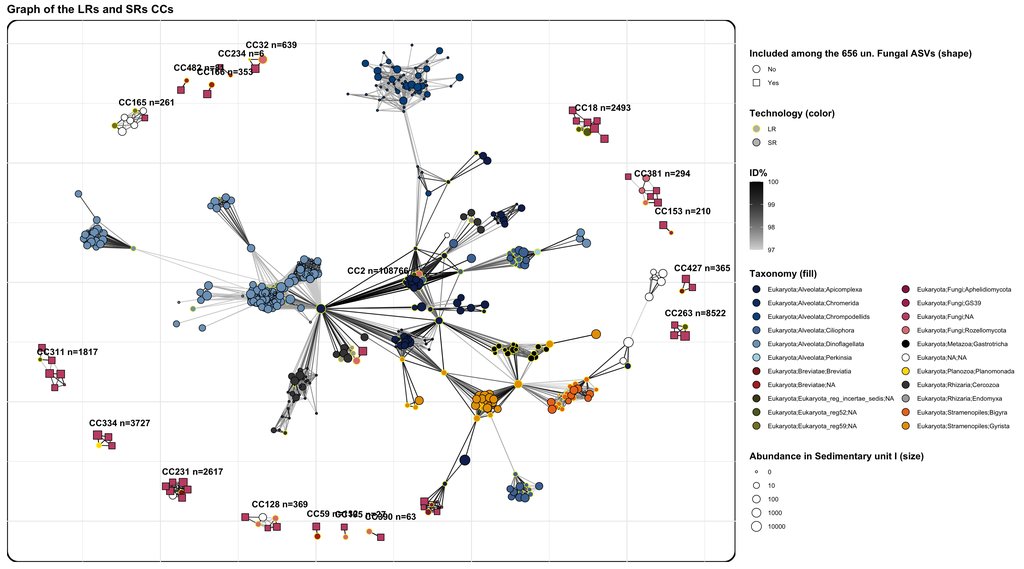

```r
# Layout
graph_ix_lay <- create_layout(graph_ix, layout = "fr")
graph_ix_lay$is656 <- ifelse(graph_ix_lay$name %in% ASVs_656_str,"Yes","No")
# Compute component centers (average positions)
comp_centers <- graph_ix_lay %>%
  as.data.frame() %>%
  group_by(CC) %>%
  summarise(x = mean(x), y = mean(y), I= sum(I[Type=="SR"]))
# Plot
ggraph(graph_ix_lay) +
  geom_edge_link(aes(edge_colour=`ID%`)) +
  geom_node_point(aes(fill=rTaxo, color=Type, shape=is656, size = ifelse(I==0,0,log10(I)))) +
  geom_text(data = comp_centers, aes(x = x, y = y, label = paste0("CC", CC, " n=",I)),
            color = "black", size = 4, fontface = "bold", nudge_y = 1.5,nudge_x = 1) +
  #geom_node_text(aes(label = ifelse(I>=1000,I,"")), colour = 'black', nudge_x = 1, nudge_y = 1) +
  scale_fill_manual(values = c("#112b5c","#0a3c70","#00538d","#4d75a3","#7da2c2","lightblue",
                               "#872720","#b13027",
                               "#4b471d","#616626","#84812d",
                               "#942450","#b13161","#c55273","#df7f87",#"#e7aea9",
                               "black",
                               "white",
                               "#ffda1c",
                               "#424242","darkgrey",
                               "#ee7620","#E69F00")) +
  scale_shape_manual(values = c(21,22)) +
  scale_edge_colour_gradient(high = "black" ,low = "#d9d9d9") +
  scale_color_manual(values = c("yellow","black")) +
  scale_size_continuous(breaks = c(0,1,2,3,4), labels = c("0","10","100","1000","10000")) +
  #scale_size_manual(values = c(3, 5)) + #facet_nodes(.~CC, scales = "free",ncol = 4) +
  labs(title="Graph of the LRs and SRs CCs",fill="Taxonomy (fill)", shape = "Included among the 656 un. Fungal ASVs (shape)", size = "Abundance in Sedimentary unit I (size)", color = "Technology (color)") +
  guides(fill = guide_legend(ncol=2,override.aes = list(shape = 21, size = 4)), color = guide_legend(override.aes = list(shape = 21, size = 4, fill = "grey")),
         size = guide_legend(override.aes = list(shape = 21)), shape = guide_legend(override.aes = list(size = 4))) +
  theme_unique_art_graph()
```

```r
ggsave(filename = "Outputs/LongReads_analysis/cluster_3_97level_V2.pdf",width=18,height=10)
```